# Assignment 1st look

## 0.1 Lib & Data

```r
library(tidyverse)
library(glue)
library(skimr)
library(naniar)
library(lubridate)
library(scales)
library(GGally)
```

```r
options(scipen = 999)
```

```r
df1 <- read_csv("Assessment-Data Scientist/DataScientistAssessment (1)/data_20160405.csv")
df1
```

| ...1 | accID | accType | accSize | accTargets | district | month | sales | qty | strategy1 | strategy2 | strategy3 | salesVisit1 | salesVisit2 | salesVisit3 | salesVisit4 | salesVisit5 | compBrand |
| --- | --- | --- | --- | --- | --- | --- | --- | --- | --- | --- | --- | --- | --- | --- | --- | --- | --- |
| 1 | XYZ-987002 | Pharmacy | 700 | 25 | 3 | 2013-10-01 | 0 | 0 | 0 | 0 | 0 | 0 | 0 | 0 | 0 | 0 | 4 |
| 2 | XYZ-987002 | Pharmacy | 700 | 25 | 3 | 2013-11-01 | 852365 | 8 | 0 | 0 | 0 | 0 | 0 | 0 | 0 | 75000 | 4 |
| 3 | XYZ-987002 | Pharmacy | 700 | 25 | 3 | 2013-12-01 | 2557096 | 25 | 0 | 0 | 0 | 0 | 0 | 0 | 0 | 0 | 4 |
| 4 | XYZ-987002 | Pharmacy | 700 | 25 | 3 | 2014-01-01 | 4261826 | 41 | 0 | 0 | 0 | 0 | 825000 | 300000 | 0 | 0 | 4 |
| 5 | XYZ-987002 | Pharmacy | 700 | 25 | 3 | 2014-02-01 | 5966556 | 57 | 0 | 0 | 0 | 0 | 0 | 0 | 0 | 0 | 4 |
| 6 | XYZ-987002 | Pharmacy | 700 | 25 | 3 | 2014-03-01 | 6818921 | 66 | 0 | 0 | 0 | 0 | 1050000 | 75000 | 0 | 0 | 4 |
| 7 | XYZ-987002 | Pharmacy | 700 | 25 | 3 | 2014-04-01 | 4261826 | 41 | 0 | 0 | 0 | 0 | 1050000 | 600000 | 0 | 0 | 4 |
| 8 | XYZ-987002 | Pharmacy | 700 | 25 | 3 | 2014-05-01 | 4261826 | 41 | 0 | 161910 | 0 | 0 | 825000 | 825000 | 0 | 0 | 4 |
| 9 | XYZ-987002 | Pharmacy | 700 | 25 | 3 | 2014-06-01 | 4261826 | 41 | 89256 | 300096 | 0 | 0 | 600000 | 975000 | 0 | 0 | 4 |
| 10 | XYZ-987002 | Pharmacy | 700 | 25 | 3 | 2014-07-01 | 6818921 | 66 | 0 | 154632 | 0 | 0 | 600000 | 1050000 | 0 | 0 | 4 |

[output cut: 990 more lines]

```r
df1 <- df1 %>%
  select(accID: last_col())

df1
```

| accID | accType | accSize | accTargets | district | month | sales | qty | strategy1 | strategy2 | strategy3 | salesVisit1 | salesVisit2 | salesVisit3 | salesVisit4 | salesVisit5 | compBrand |
| --- | --- | --- | --- | --- | --- | --- | --- | --- | --- | --- | --- | --- | --- | --- | --- | --- |
| XYZ-987002 | Pharmacy | 700 | 25 | 3 | 2013-10-01 | 0 | 0 | 0 | 0 | 0 | 0 | 0 | 0 | 0 | 0 | 4 |
| XYZ-987002 | Pharmacy | 700 | 25 | 3 | 2013-11-01 | 852365 | 8 | 0 | 0 | 0 | 0 | 0 | 0 | 0 | 75000 | 4 |
| XYZ-987002 | Pharmacy | 700 | 25 | 3 | 2013-12-01 | 2557096 | 25 | 0 | 0 | 0 | 0 | 0 | 0 | 0 | 0 | 4 |
| XYZ-987002 | Pharmacy | 700 | 25 | 3 | 2014-01-01 | 4261826 | 41 | 0 | 0 | 0 | 0 | 825000 | 300000 | 0 | 0 | 4 |
| XYZ-987002 | Pharmacy | 700 | 25 | 3 | 2014-02-01 | 5966556 | 57 | 0 | 0 | 0 | 0 | 0 | 0 | 0 | 0 | 4 |
| XYZ-987002 | Pharmacy | 700 | 25 | 3 | 2014-03-01 | 6818921 | 66 | 0 | 0 | 0 | 0 | 1050000 | 75000 | 0 | 0 | 4 |
| XYZ-987002 | Pharmacy | 700 | 25 | 3 | 2014-04-01 | 4261826 | 41 | 0 | 0 | 0 | 0 | 1050000 | 600000 | 0 | 0 | 4 |
| XYZ-987002 | Pharmacy | 700 | 25 | 3 | 2014-05-01 | 4261826 | 41 | 0 | 161910 | 0 | 0 | 825000 | 825000 | 0 | 0 | 4 |
| XYZ-987002 | Pharmacy | 700 | 25 | 3 | 2014-06-01 | 4261826 | 41 | 89256 | 300096 | 0 | 0 | 600000 | 975000 | 0 | 0 | 4 |
| XYZ-987002 | Pharmacy | 700 | 25 | 3 | 2014-07-01 | 6818921 | 66 | 0 | 154632 | 0 | 0 | 600000 | 1050000 | 0 | 0 | 4 |

[output cut: 990 more lines]

## 0.2 Data Prep & EDA

```r
summary(df1)
```

```
    accID             accType             accSize         accTargets        district
 Length:2976        Length:2976        Min.   :   0.0   Min.   :  1.00   Min.   :3
 Class :character   Class :character   1st Qu.:  60.0   1st Qu.:  2.00   1st Qu.:3
 Mode  :character   Mode  :character   Median : 240.0   Median :  9.50   Median :3
                                       Mean   : 364.2   Mean   : 15.02   Mean   :3
                                       3rd Qu.: 522.5   3rd Qu.: 20.25   3rd Qu.:3
                                       Max.   :2460.0   Max.   :102.00   Max.   :3
     month                sales               qty           strategy1         strategy2
 Min.   :2013-10-01   Min.   :-5540374   Min.   :-21.00   Min.   :      0   Min.   :      0
 1st Qu.:2014-03-24   1st Qu.:       0   1st Qu.:  0.00   1st Qu.:      0   1st Qu.:      0
 Median :2014-09-16   Median :  852365   Median :  8.00   Median :      0   Median :      0
 Mean   :2014-09-15   Mean   : 4251100   Mean   : 40.49   Mean   :  33322   Mean   : 159400
 3rd Qu.:2015-03-08   3rd Qu.: 5114191   3rd Qu.: 49.00   3rd Qu.:      0   3rd Qu.:  18950
 Max.   :2015-09-01   Max.   :51994276   Max.   :500.00   Max.   :2662031   Max.   :3161384
   strategy3        salesVisit1       salesVisit2       salesVisit3       salesVisit4
 Min.   :      0   Min.   :      0   Min.   :      0   Min.   :      0   Min.   :      0
 1st Qu.:      0   1st Qu.:      0   1st Qu.:      0   1st Qu.:      0   1st Qu.:      0
 Median :      0   Median :      0   Median : 150000   Median :  75000   Median :      0
 Mean   :   6925   Mean   :  30544   Mean   : 470539   Mean   : 434299   Mean   :  16457
 3rd Qu.:      0   3rd Qu.:      0   3rd Qu.: 600000   3rd Qu.: 600000   3rd Qu.:      0
 Max.   :2236600   Max.   :6750000   Max.   :7125000   Max.   :6075000   Max.   :1125000
  salesVisit5       compBrand
 Min.   :     0   Min.   :4.000
 1st Qu.:     0   1st Qu.:4.000
 Median :     0   Median :4.000
 Mean   :  3402   Mean   :4.167
 3rd Qu.:     0   3rd Qu.:4.000
 Max.   :375000   Max.   :5.000
```

### 0.2.1 missing data

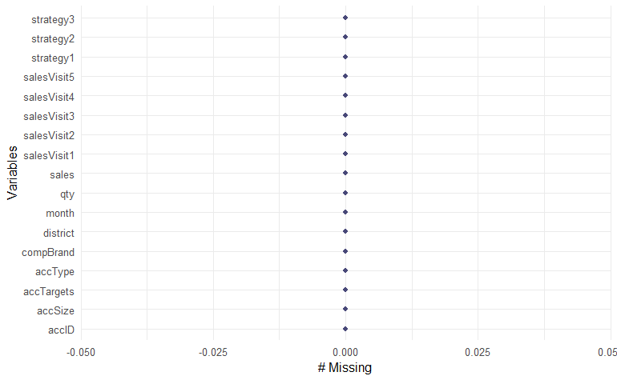

```r
naniar::gg_miss_var(df1)
```

```r
skimr::skim(df1)
```

```
── Data Summary ────────────────────────
                           Values
Name                       df1
Number of rows             2976
Number of columns          17
_______________________
Column type frequency:
  character                2
  Date                     1
  numeric                  14
________________________
Group variables            None
```

|  | skim_variable | n_missing | complete_rate | min | max | empty | n_unique | whitespace |
| --- | --- | --- | --- | --- | --- | --- | --- | --- |
| 1 | accID | 0 | 1 | 10 | 10 | 0 | 124 | 0 |
| 2 | accType | 0 | 1 | 8 | 14 | 0 | 4 | 0 |

|  | skim_variable | n_missing | complete_rate | min | max | median | n_unique |
| --- | --- | --- | --- | --- | --- | --- | --- |
| 1 | month | 0 | 1 | 2013-10-01 | 2015-09-01 | 2014-09-16 | 24 |

|  | skim_variable | n_missing | complete_rate | mean | sd | p0 | p25 | p50 | p75 | p100 | hist |
| --- | --- | --- | --- | --- | --- | --- | --- | --- | --- | --- | --- |
| 1 | accSize | 0 | 1 | 364.233871 | 417.4621836 | 0 | 60 | 240.0 | 522.50 | 2460 | ▇▂▁▁▁ |
| 2 | accTargets | 0 | 1 | 15.016129 | 17.4084228 | 1 | 2 | 9.5 | 20.25 | 102 | ▇▂▁▁▁ |
| 3 | district | 0 | 1 | 3.000000 | 0.0000000 | 3 | 3 | 3.0 | 3.00 | 3 | ▁▁▇▁▁ |
| 4 | sales | 0 | 1 | 4251099.722782 | 7564507.5349809 | -5540374 | 0 | 852365.0 | 5114191.00 | 51994276 | ▇▂▁▁▁ |
| 5 | qty | 0 | 1 | 40.488239 | 72.1379947 | -21 | 0 | 8.0 | 49.00 | 500 | ▇▁▁▁▁ |
| 6 | strategy1 | 0 | 1 | 33322.084005 | 168150.0364817 | 0 | 0 | 0.0 | 0.00 | 2662031 | ▇▁▁▁▁ |
| 7 | strategy2 | 0 | 1 | 159399.675067 | 401764.5057344 | 0 | 0 | 0.0 | 18949.50 | 3161384 | ▇▁▁▁▁ |
| 8 | strategy3 | 0 | 1 | 6924.982863 | 89119.3864326 | 0 | 0 | 0.0 | 0.00 | 2236600 | ▇▁▁▁▁ |
| 9 | salesVisit1 | 0 | 1 | 30544.354839 | 240670.2951616 | 0 | 0 | 0.0 | 0.00 | 6750000 | ▇▁▁▁▁ |
| 10 | salesVisit2 | 0 | 1 | 470539.314516 | 789997.9064753 | 0 | 0 | 150000.0 | 600000.00 | 7125000 | ▇▁▁▁▁ |

[output cut: 4 more lines]

### 0.2.2 Vars Cardinality

```r
# checking count of unique values in each variable
df1 %>% map_df(n_unique)
```

| accID | accType | accSize | accTargets | district | month | sales | qty | strategy1 | strategy2 | strategy3 | salesVisit1 | salesVisit2 | salesVisit3 | salesVisit4 | salesVisit5 | compBrand |
| --- | --- | --- | --- | --- | --- | --- | --- | --- | --- | --- | --- | --- | --- | --- | --- | --- |
| 124 | 4 | 71 | 39 | 1 | 24 | 160 | 133 | 219 | 754 | 29 | 27 | 67 | 69 | 16 | 6 | 2 |

```r
# checking variables with count of unique values less than 20
df1 %>%
  map_df(n_unique) %>%
  pivot_longer(cols = dplyr::everything(),
               names_to = "vars",
               values_to = "distinct_count",) %>%
  filter(distinct_count < 20)
```

| vars | distinct_count |
| --- | --- |
| accType | 4 |
| district | 1 |
| salesVisit4 | 16 |
| salesVisit5 | 6 |
| compBrand | 2 |

```r
# data distribution by accType
df1$accType %>% table()
```

```
.
      Hospital       Pharmacy     Polyclinic Private Clinic
          1368            504            840            264
```

```r
# data distribution by distict
df1$district %>% table()
```

```
.
   3
2976
```

```r
# data distribution by salesVisit5
df1$salesVisit5 %>% table()
```

```
.
     0  75000 150000 225000 300000 375000
  2871     86     14      1      2      2
```

```r
# data distribution by compBrand
df1$compBrand %>% table()
```

```
.
   4    5
2480  496
```

#### 0.2.2.1 Vars to factor

converting character & low cardinality variables to factors

```r
df1 <- df1 %>%
  mutate(across(.cols = c(accType, district, compBrand), .fns = factor))

df1
```

| accID | accType | accSize | accTargets | district | month | sales | qty | strategy1 | strategy2 | strategy3 | salesVisit1 | salesVisit2 | salesVisit3 | salesVisit4 | salesVisit5 | compBrand |
| --- | --- | --- | --- | --- | --- | --- | --- | --- | --- | --- | --- | --- | --- | --- | --- | --- |
| XYZ-987002 | Pharmacy | 700 | 25 | 3 | 2013-10-01 | 0 | 0 | 0 | 0 | 0 | 0 | 0 | 0 | 0 | 0 | 4 |
| XYZ-987002 | Pharmacy | 700 | 25 | 3 | 2013-11-01 | 852365 | 8 | 0 | 0 | 0 | 0 | 0 | 0 | 0 | 75000 | 4 |
| XYZ-987002 | Pharmacy | 700 | 25 | 3 | 2013-12-01 | 2557096 | 25 | 0 | 0 | 0 | 0 | 0 | 0 | 0 | 0 | 4 |
| XYZ-987002 | Pharmacy | 700 | 25 | 3 | 2014-01-01 | 4261826 | 41 | 0 | 0 | 0 | 0 | 825000 | 300000 | 0 | 0 | 4 |
| XYZ-987002 | Pharmacy | 700 | 25 | 3 | 2014-02-01 | 5966556 | 57 | 0 | 0 | 0 | 0 | 0 | 0 | 0 | 0 | 4 |
| XYZ-987002 | Pharmacy | 700 | 25 | 3 | 2014-03-01 | 6818921 | 66 | 0 | 0 | 0 | 0 | 1050000 | 75000 | 0 | 0 | 4 |
| XYZ-987002 | Pharmacy | 700 | 25 | 3 | 2014-04-01 | 4261826 | 41 | 0 | 0 | 0 | 0 | 1050000 | 600000 | 0 | 0 | 4 |
| XYZ-987002 | Pharmacy | 700 | 25 | 3 | 2014-05-01 | 4261826 | 41 | 0 | 161910 | 0 | 0 | 825000 | 825000 | 0 | 0 | 4 |
| XYZ-987002 | Pharmacy | 700 | 25 | 3 | 2014-06-01 | 4261826 | 41 | 89256 | 300096 | 0 | 0 | 600000 | 975000 | 0 | 0 | 4 |
| XYZ-987002 | Pharmacy | 700 | 25 | 3 | 2014-07-01 | 6818921 | 66 | 0 | 154632 | 0 | 0 | 600000 | 1050000 | 0 | 0 | 4 |

[output cut: 990 more lines]

### 0.2.3 Adding date vars

```r
df1 <- df1 %>%
  mutate(month_only = lubridate::month(month, abbr = T, label = T),
         month_only = factor(month_only, levels = month.abb),
         year_only = factor(lubridate::year(month))) %>%

  select(accID, year_only, month_only, month, dplyr::everything())

df1
```

| accID | year_only | month_only | month | accType | accSize | accTargets | district | sales | qty | strategy1 | strategy2 | strategy3 | salesVisit1 | salesVisit2 | salesVisit3 | salesVisit4 | salesVisit5 | compBrand |
| --- | --- | --- | --- | --- | --- | --- | --- | --- | --- | --- | --- | --- | --- | --- | --- | --- | --- | --- |
| XYZ-987002 | 2013 | Oct | 2013-10-01 | Pharmacy | 700 | 25 | 3 | 0 | 0 | 0 | 0 | 0 | 0 | 0 | 0 | 0 | 0 | 4 |
| XYZ-987002 | 2013 | Nov | 2013-11-01 | Pharmacy | 700 | 25 | 3 | 852365 | 8 | 0 | 0 | 0 | 0 | 0 | 0 | 0 | 75000 | 4 |
| XYZ-987002 | 2013 | Dec | 2013-12-01 | Pharmacy | 700 | 25 | 3 | 2557096 | 25 | 0 | 0 | 0 | 0 | 0 | 0 | 0 | 0 | 4 |
| XYZ-987002 | 2014 | Jan | 2014-01-01 | Pharmacy | 700 | 25 | 3 | 4261826 | 41 | 0 | 0 | 0 | 0 | 825000 | 300000 | 0 | 0 | 4 |
| XYZ-987002 | 2014 | Feb | 2014-02-01 | Pharmacy | 700 | 25 | 3 | 5966556 | 57 | 0 | 0 | 0 | 0 | 0 | 0 | 0 | 0 | 4 |
| XYZ-987002 | 2014 | Mar | 2014-03-01 | Pharmacy | 700 | 25 | 3 | 6818921 | 66 | 0 | 0 | 0 | 0 | 1050000 | 75000 | 0 | 0 | 4 |
| XYZ-987002 | 2014 | Apr | 2014-04-01 | Pharmacy | 700 | 25 | 3 | 4261826 | 41 | 0 | 0 | 0 | 0 | 1050000 | 600000 | 0 | 0 | 4 |
| XYZ-987002 | 2014 | May | 2014-05-01 | Pharmacy | 700 | 25 | 3 | 4261826 | 41 | 0 | 161910 | 0 | 0 | 825000 | 825000 | 0 | 0 | 4 |
| XYZ-987002 | 2014 | Jun | 2014-06-01 | Pharmacy | 700 | 25 | 3 | 4261826 | 41 | 89256 | 300096 | 0 | 0 | 600000 | 975000 | 0 | 0 | 4 |
| XYZ-987002 | 2014 | Jul | 2014-07-01 | Pharmacy | 700 | 25 | 3 | 6818921 | 66 | 0 | 154632 | 0 | 0 | 600000 | 1050000 | 0 | 0 | 4 |

[output cut: 990 more lines]

### 0.2.4 Exploration

#### 0.2.4.1 Correlation Plot

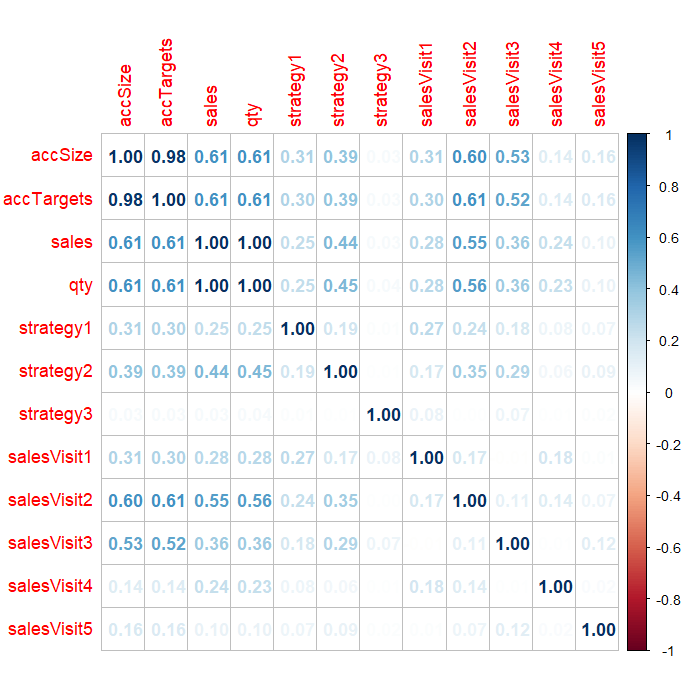

```r
df1 %>%
  select_if(is.numeric) %>%
  cor() %>%
  corrplot::corrplot(method = "number")
```

#### 0.2.4.2 Other EDA

data distribution for accTYpe & Brand

```r
# data distribution for accTYpe & Brand
prop.table(table(df1$accType, df1$compBrand))
```

```
                          4          5
  Hospital       0.38306452 0.07661290
  Pharmacy       0.14112903 0.02822581
  Polyclinic     0.23521505 0.04704301
  Private Clinic 0.07392473 0.01478495
```

data distribution for accTYpe & Brand in %

```r
# data distribution for accTYpe & Brand in %
prop.table(table(df1$accType, df1$compBrand)) * 100
```

```
                         4         5
  Hospital       38.306452  7.661290
  Pharmacy       14.112903  2.822581
  Polyclinic     23.521505  4.704301
  Private Clinic  7.392473  1.478495
```

From above, Seems like we have lot more data for **Comp Brand 4**.

Below, summarising some imp numeric vars by brand, year & account type

```r
# summarising some imp numeric vars by brand, year & account type
df1 %>%
  group_by(compBrand, year_only, accType) %>%
  summarise_at(c("accSize", "accTargets", "qty"), sum, na.rm = T)
```

| compBrand | year_only | accType | accSize | accTargets | qty |
| --- | --- | --- | --- | --- | --- |
| 4 | 2013 | Hospital | 59031 | 2448 | 1867 |
| 4 | 2013 | Pharmacy | 62067 | 2556 | 434 |
| 4 | 2013 | Polyclinic | 11091 | 447 | 40 |
| 4 | 2013 | Private Clinic | 3306 | 135 | 187 |
| 4 | 2014 | Hospital | 236124 | 9792 | 25610 |
| 4 | 2014 | Pharmacy | 248268 | 10224 | 17093 |
| 4 | 2014 | Polyclinic | 44364 | 1788 | 650 |
| 4 | 2014 | Private Clinic | 13224 | 540 | 1572 |
| 4 | 2015 | Hospital | 98385 | 4080 | 19811 |
| 4 | 2015 | Pharmacy | 103445 | 4260 | 16091 |

[output cut: 6 more lines]

summarising accountsize by year & account type for Comp Brand 4

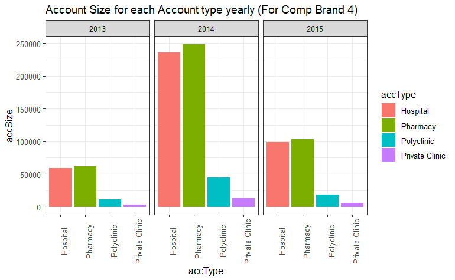

```r
# summarising accountsize by year & account type for Comp Brand 4
df1 %>%
  group_by(compBrand, year_only, accType) %>%
  summarise_at(c("accSize", "accTargets", "qty"), sum, na.rm = T) %>%

  filter(compBrand == "4") %>%

  ggplot(aes(x = accType, y = accSize, fill = accType)) +
  geom_col() +
  facet_wrap(~year_only) +
  theme_bw() +
  theme(axis.text.x = element_text(angle = 90)) +
  labs(title = "Account Size for each Account type yearly (For Comp Brand 4)")
```

Account Size for each Account type yearly (For all Brands)

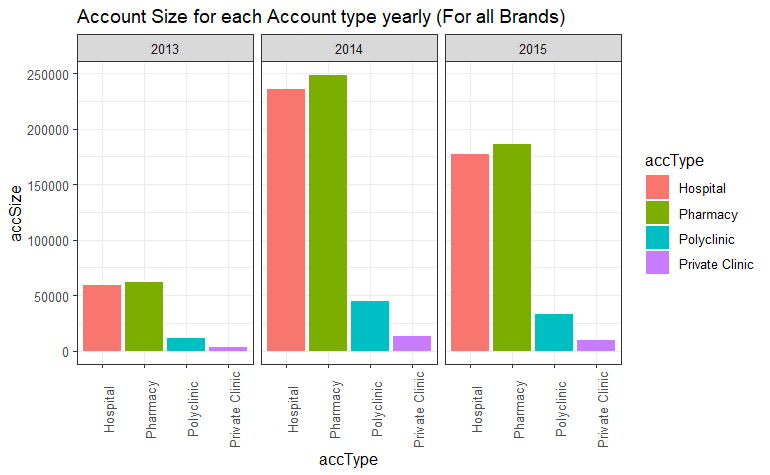

```r
df1 %>%
  group_by(year_only, accType) %>%
  summarise_at(c("accSize", "accTargets", "qty"), sum, na.rm = T) %>%

  # filter(compBrand == "4") %>%

  ggplot(aes(x = accType, y = accSize, fill = accType)) +
  geom_col() +
  facet_wrap(~year_only) +
  theme_bw() +
  theme(axis.text.x = element_text(angle = 90)) +
  labs(title = "Account Size for each Account type yearly (For all Brands)")
```

Above, account size remains same for 2013 & 2014 but changes in 2015 when All Brands are used

Below, Total account size by months across years

```r
# Total account size by months across years
df1 %>%
  arrange(month) %>%
  group_by(year_only, month_only) %>%
  summarise(accSize = sum(accSize), .groups = "drop") %>%
  pivot_wider(id_cols = month_only, names_from = year_only, values_from = accSize) %>%
  arrange(month_only)
```

| month_only | 2013 | 2014 | 2015 |
| --- | --- | --- | --- |
| Jan | NA | 45165 | 45165 |
| Feb | NA | 45165 | 45165 |
| Mar | NA | 45165 | 45165 |
| Apr | NA | 45165 | 45165 |
| May | NA | 45165 | 45165 |
| Jun | NA | 45165 | 45165 |
| Jul | NA | 45165 | 45165 |
| Aug | NA | 45165 | 45165 |
| Sep | NA | 45165 | 45165 |
| Oct | 45165 | 45165 | NA |

[output cut: 2 more lines]

Above, total account Size remains same for all the months.

Below, Total account Target by months across years

```r
# Total account Target by months across years
df1 %>%
  arrange(month) %>%
  group_by(year_only, month_only) %>%
  summarise(accTargets = sum(accTargets), .groups = "drop") %>%
  pivot_wider(id_cols = month_only, names_from = year_only, values_from = accTargets) %>%
  arrange(month_only)
```

| month_only | 2013 | 2014 | 2015 |
| --- | --- | --- | --- |
| Jan | NA | 1862 | 1862 |
| Feb | NA | 1862 | 1862 |
| Mar | NA | 1862 | 1862 |
| Apr | NA | 1862 | 1862 |
| May | NA | 1862 | 1862 |
| Jun | NA | 1862 | 1862 |
| Jul | NA | 1862 | 1862 |
| Aug | NA | 1862 | 1862 |
| Sep | NA | 1862 | 1862 |
| Oct | 1862 | 1862 | NA |

[output cut: 2 more lines]

Above, Account Target remains same across the years

Below, Total sales by months & years

```r
# Total sales by months & years
df1 %>%
  arrange(month) %>%
  group_by(year_only, month_only) %>%
  summarise(sales = sum(sales), .groups = "drop") %>%
  pivot_wider(id_cols = month_only, names_from = year_only, values_from = sales) %>%
  arrange(month_only)
```

| month_only | 2013 | 2014 | 2015 |
| --- | --- | --- | --- |
| Jan | NA | 142387603 | 776376824 |
| Feb | NA | 181127597 | 658281631 |
| Mar | NA | 228860049 | 755621733 |
| Apr | NA | 284263785 | 942033998 |
| May | NA | 287928955 | 810215724 |
| Jun | NA | 302973200 | 807956951 |
| Jul | NA | 436496207 | 936024820 |
| Aug | NA | 456782495 | 945869637 |
| Sep | NA | 514828567 | 998886752 |
| Oct | 63842150 | 570061834 | NA |

[output cut: 2 more lines]

Below, Total sales by months & years for Comp Brand 4 only

```r
# Total sales by months & years for Comp Brand 4 only
df1 %>% filter(compBrand == 4) %>%
  arrange(month) %>%
  group_by(year_only, month_only) %>%
  summarise(sales = sum(sales), .groups = "drop") %>%
  pivot_wider(id_cols = month_only, names_from = year_only, values_from = sales) %>%
  arrange(month_only)
```

| month_only | 2013 | 2014 | 2015 |
| --- | --- | --- | --- |
| Jan | NA | 142387603 | 776376824 |
| Feb | NA | 181127597 | 658281631 |
| Mar | NA | 228860049 | 755621733 |
| Apr | NA | 284263785 | 942033998 |
| May | NA | 287928955 | 810215724 |
| Jun | NA | 302973200 | NA |
| Jul | NA | 436496207 | NA |
| Aug | NA | 456782495 | NA |
| Sep | NA | 514828567 | NA |
| Oct | 63842150 | 570061834 | NA |

[output cut: 2 more lines]

Above, seems like sales of Comp Brand 4 stopped from Jun’2015 onward & Brand 5 started from that period

Below, Total Sales timeline by Comp Brand type

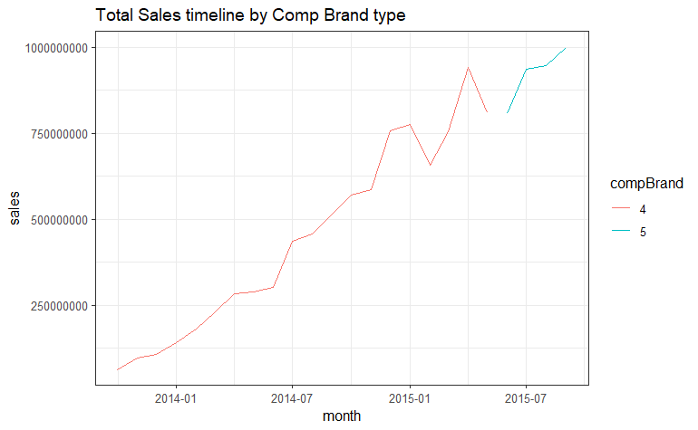

```r
df1 %>%
  arrange(month) %>%
  group_by(compBrand, month) %>%
  summarise(sales = sum(sales), .groups = "drop") %>%

  ggplot(aes(x = month, y = sales, group = compBrand, col = compBrand)) +
  geom_line() +
  theme_bw() +
  labs(title = "Total Sales timeline by Comp Brand type")
```

Above, Brand 5 started selling from 2015 only & same time Brand 4 stopped selling

Below, Checking data for Comp Brand 5

```r
df1 %>%
  filter(compBrand == 5) %>%
  arrange(month)
```

| accID | year_only | month_only | month | accType | accSize | accTargets | district | sales | qty | strategy1 | strategy2 | strategy3 | salesVisit1 | salesVisit2 | salesVisit3 | salesVisit4 | salesVisit5 | compBrand |
| --- | --- | --- | --- | --- | --- | --- | --- | --- | --- | --- | --- | --- | --- | --- | --- | --- | --- | --- |
| XYZ-987002 | 2015 | Jun | 2015-06-01 | Pharmacy | 700 | 25 | 3 | 11933113 | 115 | 0 | 115380 | 0 | 0 | 375000 | 1950000 | 0 | 0 | 5 |
| XYZ-987005 | 2015 | Jun | 2015-06-01 | Hospital | 790 | 24 | 3 | 25570955 | 246 | 70000 | 0 | 0 | 0 | 750000 | 225000 | 0 | 0 | 5 |
| XYZ-987006 | 2015 | Jun | 2015-06-01 | Hospital | 320 | 14 | 3 | 5966556 | 57 | 0 | 0 | 0 | 0 | 900000 | 225000 | 0 | 0 | 5 |
| XYZ-987007 | 2015 | Jun | 2015-06-01 | Pharmacy | 1000 | 36 | 3 | 27275686 | 262 | 35000 | 407142 | 0 | 0 | 375000 | 0 | 0 | 0 | 5 |
| XYZ-987008 | 2015 | Jun | 2015-06-01 | Hospital | 440 | 18 | 3 | 16194938 | 156 | 70000 | 0 | 0 | 150000 | 150000 | 150000 | 300000 | 0 | 5 |
| XYZ-987009 | 2015 | Jun | 2015-06-01 | Pharmacy | 520 | 19 | 3 | 7671287 | 74 | 140000 | 0 | 0 | 0 | 450000 | 600000 | 0 | 0 | 5 |
| XYZ-987010 | 2015 | Jun | 2015-06-01 | Hospital | 670 | 27 | 3 | 14490208 | 139 | 35000 | 0 | 0 | 0 | 975000 | 300000 | 0 | 0 | 5 |
| XYZ-987014 | 2015 | Jun | 2015-06-01 | Polyclinic | 240 | 6 | 3 | 426183 | 4 | 0 | 0 | 0 | 0 | 0 | 0 | 0 | 0 | 5 |
| XYZ-987015 | 2015 | Jun | 2015-06-01 | Hospital | 210 | 8 | 3 | 6818921 | 66 | 0 | 0 | 0 | 0 | 150000 | 0 | 0 | 0 | 5 |
| XYZ-987016 | 2015 | Jun | 2015-06-01 | Hospital | 200 | 6 | 3 | 852365 | 8 | 0 | 0 | 0 | 0 | 0 | 0 | 0 | 0 | 5 |

[output cut: 486 more lines]

Below, Yearly Growth of Total Sales by Account type

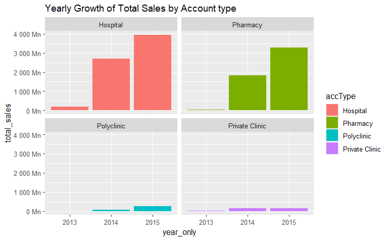

```r
df1 %>%
  arrange(month) %>%
  group_by(year_only, accType) %>%
  summarise(total_sales = sum(sales), .groups = "drop") %>%

  ggplot(aes(x = year_only, y = total_sales, fill = accType)) +
  geom_col() +
  facet_wrap(~accType) +
  scale_y_continuous(labels = unit_format(unit = "Mn", scale = 1e-6)) +
  labs(title = "Yearly Growth of Total Sales by Account type")
```

Above, except `Private` all other account types have more sales in 2015 in comparison to historical years

Below, Growth of Total Sales by Account type (for Comp Brand 4)

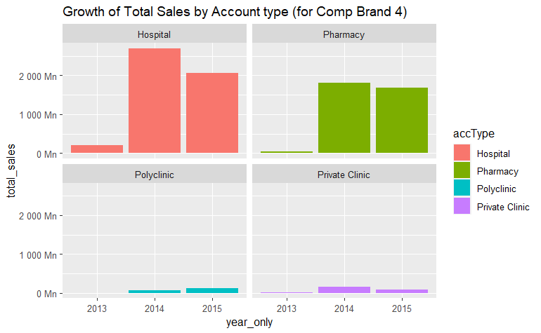

```r
df1 %>% filter(compBrand == 4) %>%
  arrange(month) %>%
  group_by(year_only, accType) %>%
  summarise(total_sales = sum(sales), .groups = "drop") %>%

  ggplot(aes(x = year_only, y = total_sales, fill = accType)) +
  geom_col() +
  facet_wrap(~accType) +
  labs(title = "Growth of Total Sales by Account type (for Comp Brand 4)") +
  scale_y_continuous(labels = unit_format(unit = "Mn", scale = 1e-6))
```

Above, for compBrand 4 - only `Polyclinic` has more sales in 2015 in comparison to historical years

Below, Sales Distribution by Comp Brand type

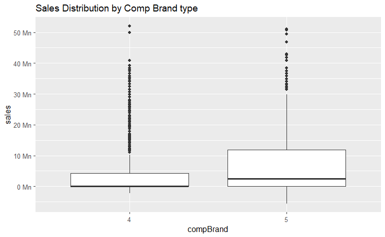

```r
# checking for sales outlier by brand
df1 %>%
  ggplot(aes(x = compBrand, y = sales)) +
  geom_boxplot() +
  scale_y_continuous(labels = unit_format(unit = "Mn", scale = 1e-6)) +
  labs(title = "Sales Distribution by Comp Brand type")
```

Below, Sales Distribution by Comp Brand type based on Time Variable

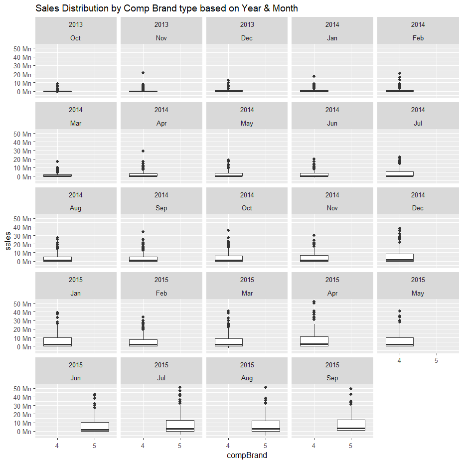

```r
df1 %>%
  ggplot(aes(x = compBrand, y = sales)) +
  geom_boxplot() +
  facet_wrap(year_only~month_only) +
  scale_y_continuous(labels = unit_format(unit = "Mn", scale = 1e-6)) +
  labs(title = "Sales Distribution by Comp Brand type based on Year & Month")
```

Below, Monthly Sales Pattern each Year

[figure not shown]

```r
df1 %>%
  group_by(year_only, month_only) %>%
  summarise(sales = sum(sales, na.rm = T), .groups = "drop") %>%

  ggplot(aes(x = month_only, y = sales, group = year_only, col = year_only)) +
  geom_line() +
  labs(title = "Monthly Sales Pattern each Year") +
  scale_y_continuous(labels = unit_format(unit = "Mn", scale = 1e-6))
```

Below, Checking for Relation ship & patterns from multiple variables using pair plots

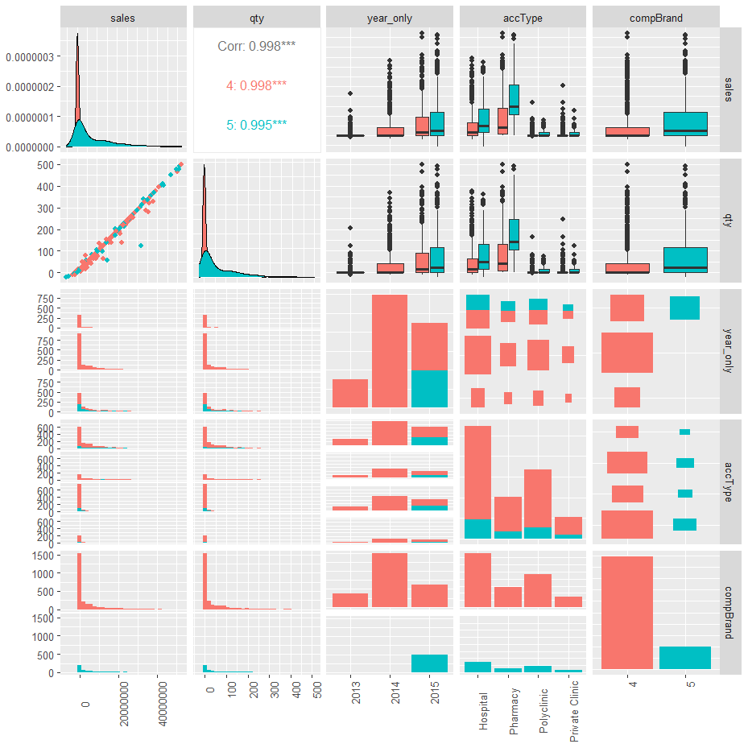

```r
df1 %>%
  select(sales, qty,  year_only, accType, compBrand) %>%
  ggpairs(aes(col = compBrand), progress = FALSE) +
  theme(axis.text.x = element_text(angle = 90))
```

From above:

1. Average Sales & Averaage qty sold overall of Brand 5 is higher than Brand 4 in all Account Types. This could probably be due to rising trend and Brand 5 being latest shows high values in all.
2. In 2015 Average Sales & Averaage qty sold of Brand 5 is higher than Brand 4
3. Qty has very high correlation with Sales which is expected.

Below, Checking for Relation ship & patterns from multiple variables using pair plots

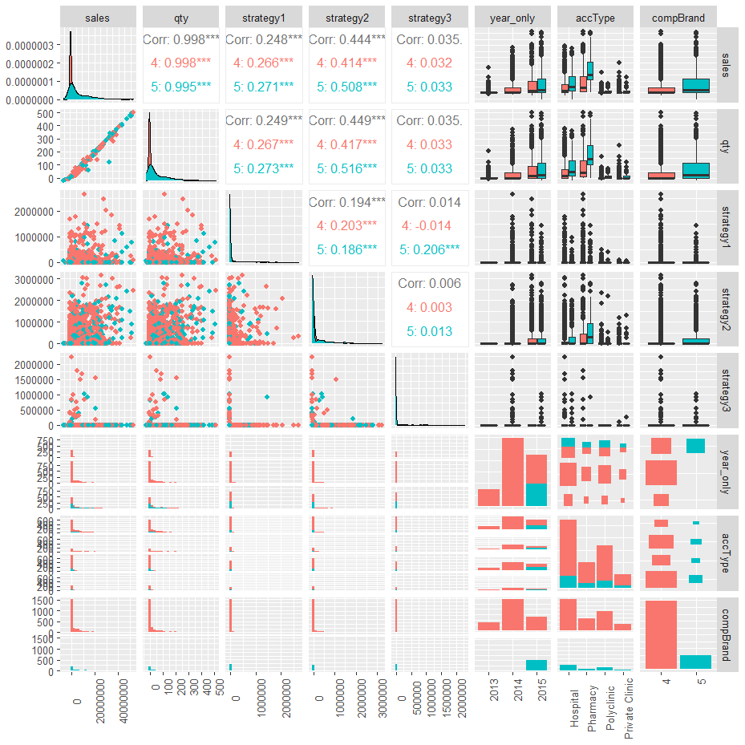

```r
df1 %>%
  select(sales, qty, strategy1, strategy2, strategy3, year_only, accType, compBrand) %>%
  ggpairs(aes(col = compBrand), progress = FALSE) +
  theme(axis.text.x = element_text(angle = 90))
```

From above, Strategy 2 has some correlation with sales & qty

Below, Checking date range for Comp Brand 4

```r
df1 %>%
  filter(compBrand == 4) %>%
  arrange(month) %>%
  select(month) %>%
  summary()
```

```
     month
 Min.   :2013-10-01
 1st Qu.:2014-02-22
 Median :2014-07-16
 Mean   :2014-07-16
 3rd Qu.:2014-12-08
 Max.   :2015-05-01
```

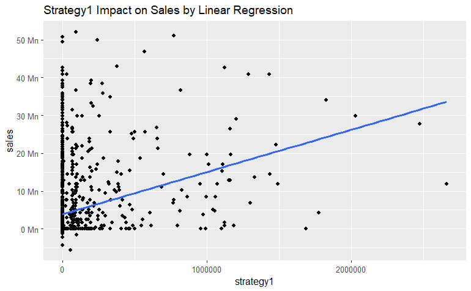

```r
df1 %>%
  ggplot(aes(x = strategy1, y = sales)) +
  geom_point() + geom_smooth(method = "lm", se = F) +
  scale_y_continuous(labels = unit_format(unit = "Mn", scale = 1e-6)) +
  labs(title = "Strategy1 Impact on Sales by Linear Regression")
```

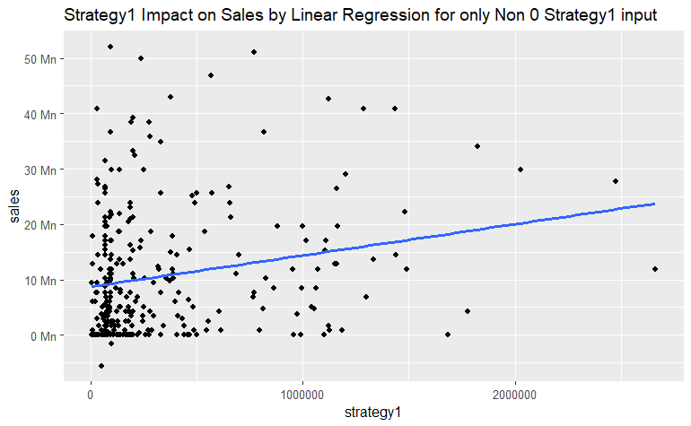

```r
df1 %>%
  filter(strategy1 != 0) %>%
  ggplot(aes(x = strategy1, y = sales)) +
  geom_point() + geom_smooth(method = "lm", se = F) +
  scale_y_continuous(labels = unit_format(unit = "Mn", scale = 1e-6)) +
  labs(title = "Strategy1 Impact on Sales by Linear Regression for only Non 0 Strategy1 input")
```

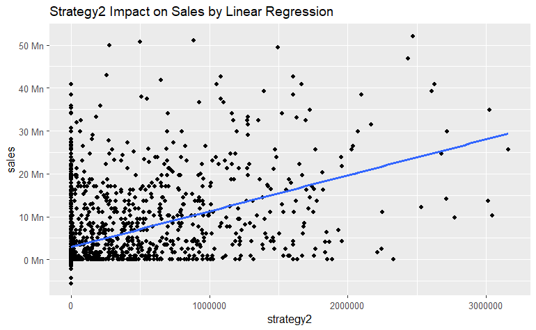

```r
df1 %>%
  ggplot(aes(x = strategy2, y = sales)) +
  scale_y_continuous(labels = unit_format(unit = "Mn", scale = 1e-6)) +
  geom_point() + geom_smooth(method = "lm", se = F) +
  labs(title = "Strategy2 Impact on Sales by Linear Regression")
```

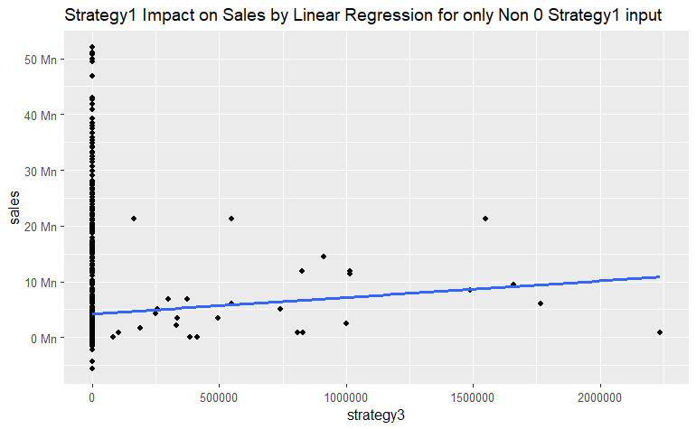

```r
df1 %>%
  ggplot(aes(x = strategy3, y = sales)) +
  geom_point() +
  geom_smooth(method = "lm", se = F) +
  scale_y_continuous(labels = unit_format(unit = "Mn", scale = 1e-6)) +
  labs(title = "Strategy1 Impact on Sales by Linear Regression for only Non 0 Strategy1 input")
```

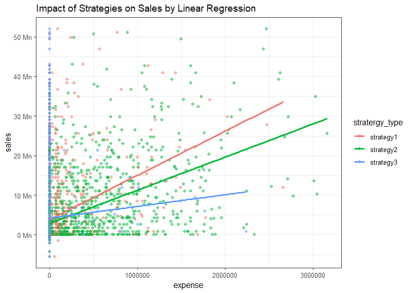

```r
df1 %>%
  pivot_longer(cols = strategy1:strategy3, names_to = "stratergy_type", values_to = "expense") %>%
  ggplot(aes(x = expense, y = sales, col = stratergy_type)) +
  geom_point(alpha = .5) +
  geom_smooth(method = "lm", se = F) +
  theme_bw() +
  scale_y_continuous(labels = unit_format(unit = "Mn", scale = 1e-6)) +
  labs(title = "Impact of Strategies on Sales by Linear Regression")
```

```r
NA
```

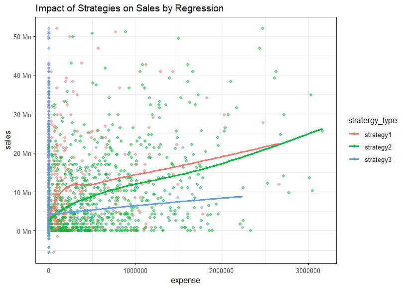

```r
df1 %>%
  pivot_longer(cols = strategy1:strategy3, names_to = "stratergy_type", values_to = "expense") %>%
  ggplot(aes(x = expense, y = sales, col = stratergy_type)) +
  geom_point(alpha = .5) +
  geom_smooth(se = F) +
  theme_bw() +
  scale_y_continuous(labels = unit_format(unit = "Mn", scale = 1e-6)) +
  labs(title = "Impact of Strategies on Sales by Regression")
```

```r
df1 %>%
  pivot_longer(cols = strategy1:strategy3, names_to = "stratergy_type", values_to = "expense") %>%
  filter(stratergy_type == "strategy1")
```

| accID | year_only | month_only | month | accType | accSize | accTargets | district | sales | qty | salesVisit1 | salesVisit2 | salesVisit3 | salesVisit4 | salesVisit5 | compBrand | stratergy_type | expense |
| --- | --- | --- | --- | --- | --- | --- | --- | --- | --- | --- | --- | --- | --- | --- | --- | --- | --- |
| XYZ-987002 | 2013 | Oct | 2013-10-01 | Pharmacy | 700 | 25 | 3 | 0 | 0 | 0 | 0 | 0 | 0 | 0 | 4 | strategy1 | 0 |
| XYZ-987002 | 2013 | Nov | 2013-11-01 | Pharmacy | 700 | 25 | 3 | 852365 | 8 | 0 | 0 | 0 | 0 | 75000 | 4 | strategy1 | 0 |
| XYZ-987002 | 2013 | Dec | 2013-12-01 | Pharmacy | 700 | 25 | 3 | 2557096 | 25 | 0 | 0 | 0 | 0 | 0 | 4 | strategy1 | 0 |
| XYZ-987002 | 2014 | Jan | 2014-01-01 | Pharmacy | 700 | 25 | 3 | 4261826 | 41 | 0 | 825000 | 300000 | 0 | 0 | 4 | strategy1 | 0 |
| XYZ-987002 | 2014 | Feb | 2014-02-01 | Pharmacy | 700 | 25 | 3 | 5966556 | 57 | 0 | 0 | 0 | 0 | 0 | 4 | strategy1 | 0 |
| XYZ-987002 | 2014 | Mar | 2014-03-01 | Pharmacy | 700 | 25 | 3 | 6818921 | 66 | 0 | 1050000 | 75000 | 0 | 0 | 4 | strategy1 | 0 |
| XYZ-987002 | 2014 | Apr | 2014-04-01 | Pharmacy | 700 | 25 | 3 | 4261826 | 41 | 0 | 1050000 | 600000 | 0 | 0 | 4 | strategy1 | 0 |
| XYZ-987002 | 2014 | May | 2014-05-01 | Pharmacy | 700 | 25 | 3 | 4261826 | 41 | 0 | 825000 | 825000 | 0 | 0 | 4 | strategy1 | 0 |
| XYZ-987002 | 2014 | Jun | 2014-06-01 | Pharmacy | 700 | 25 | 3 | 4261826 | 41 | 0 | 600000 | 975000 | 0 | 0 | 4 | strategy1 | 89256 |
| XYZ-987002 | 2014 | Jul | 2014-07-01 | Pharmacy | 700 | 25 | 3 | 6818921 | 66 | 0 | 600000 | 1050000 | 0 | 0 | 4 | strategy1 | 0 |

[output cut: 990 more lines]

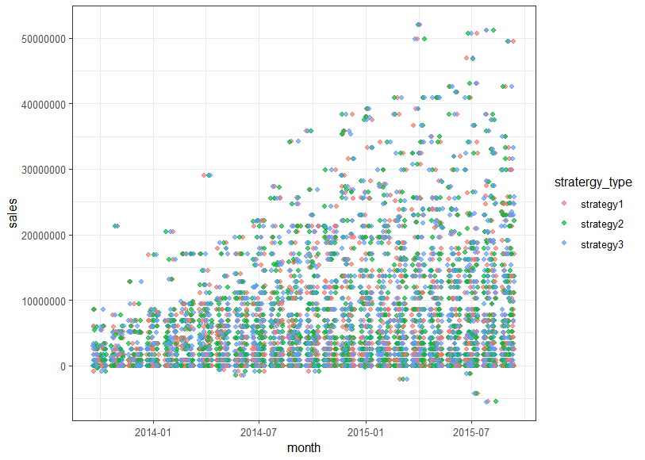

```r
df1 %>%
  pivot_longer(cols = strategy1:strategy3, names_to = "stratergy_type", values_to = "expense") %>%
  ggplot(aes(x = month, y = sales, col = stratergy_type)) +
  geom_jitter(alpha = .7) +
  # geom_smooth(method = 'lm') +
  theme_bw()
```

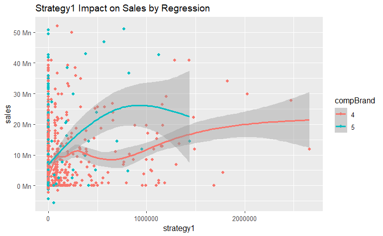

```r
df1 %>%
  ggplot(aes(x = strategy1, y = sales, col = compBrand)) +
  geom_point() +
  geom_smooth() +
  scale_y_continuous(labels = unit_format(unit = "Mn", scale = 1e-6)) +
  labs(title = "Strategy1 Impact on Sales by Regression")
```

Above plot, Strategy 1 for Brand 5 is showing Diminishing Returns and it attained peak around 800k-900k strategy1.

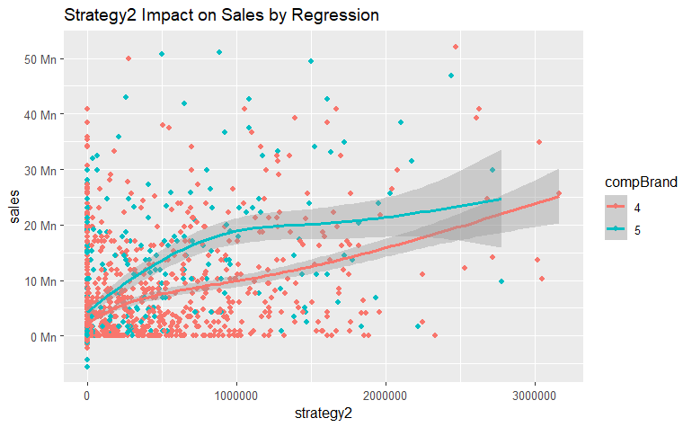

```r
df1 %>%
  ggplot(aes(x = strategy2, y = sales, col = compBrand)) +
  geom_point() +
  geom_smooth() +
  scale_y_continuous(labels = unit_format(unit = "Mn", scale = 1e-6)) +
  labs(title = "Strategy2 Impact on Sales by Regression")
```

Above plot,

Strategy 2 for Brand 4 doesn’t show as much elasticity as in Brand 4 but still growth remains constant & doesnt peak before end.

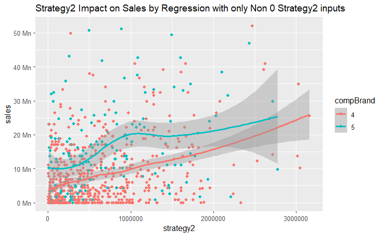

```r
df1 %>%
  filter(strategy2 != 0) %>%
  ggplot(aes(x = strategy2, y = sales, col = compBrand)) +
  geom_point() +
  geom_smooth() +
  scale_y_continuous(labels = unit_format(unit = "Mn", scale = 1e-6)) +
  labs(title = "Strategy2 Impact on Sales by Regression with only Non 0 Strategy2 inputs")
```

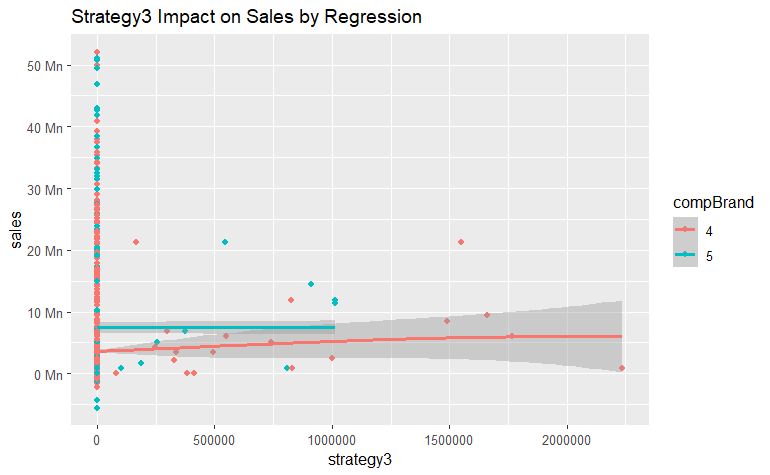

```r
df1 %>%
  ggplot(aes(x = strategy3, y = sales, col = compBrand)) +
  geom_point() +
  geom_smooth() +
  scale_y_continuous(labels = unit_format(unit = "Mn", scale = 1e-6)) +
  labs(title = "Strategy3 Impact on Sales by Regression")
```

Above plot, Strategy 3 doesn’t seems to make much of difference in driving sales as majority of it as 0 strategy value.

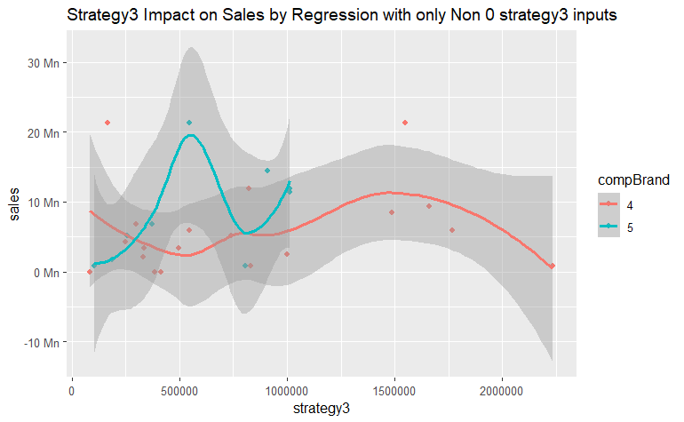

```r
df1 %>%
  filter(strategy3 != 0) %>%
  ggplot(aes(x = strategy3, y = sales, col = compBrand)) +
  geom_point() +
  geom_smooth() +
  scale_y_continuous(labels = unit_format(unit = "Mn", scale = 1e-6)) +
  labs(title = "Strategy3 Impact on Sales by Regression with only Non 0 strategy3 inputs")
```

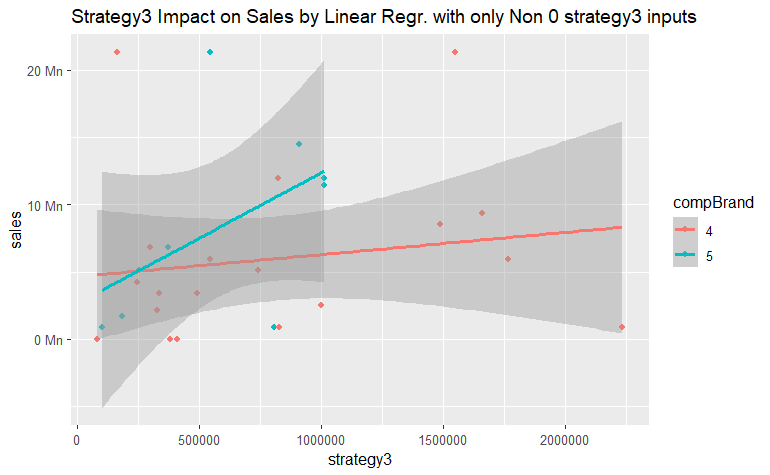

```r
df1 %>%
  filter(strategy3 != 0) %>%
  ggplot(aes(x = strategy3, y = sales, col = compBrand)) +
  geom_point() +
  geom_smooth(method = "lm") +
  scale_y_continuous(labels = unit_format(unit = "Mn", scale = 1e-6)) +
  labs(title = "Strategy3 Impact on Sales by Linear Regr. with only Non 0 strategy3 inputs")
```

Checking for Account ID below

```r
df1$accID %>% table()
```

```
.
XYZ-987002 XYZ-987005 XYZ-987006 XYZ-987007 XYZ-987008 XYZ-987009 XYZ-987010 XYZ-987014 XYZ-987015
        24         24         24         24         24         24         24         24         24
XYZ-987016 XYZ-987017 XYZ-987019 XYZ-987021 XYZ-987022 XYZ-987023 XYZ-987024 XYZ-987025 XYZ-987026
        24         24         24         24         24         24         24         24         24
XYZ-987027 XYZ-987029 XYZ-987030 XYZ-987032 XYZ-987033 XYZ-987034 XYZ-987035 XYZ-987036 XYZ-987037
        24         24         24         24         24         24         24         24         24
XYZ-987039 XYZ-987043 XYZ-987045 XYZ-987047 XYZ-987049 XYZ-987050 XYZ-987052 XYZ-987054 XYZ-987056
        24         24         24         24         24         24         24         24         24
XYZ-987059 XYZ-987060 XYZ-987061 XYZ-987062 XYZ-987063 XYZ-987065 XYZ-987067 XYZ-987069 XYZ-987070
        24         24         24         24         24         24         24         24         24
XYZ-987071 XYZ-987072 XYZ-987075 XYZ-987077 XYZ-987079 XYZ-987081 XYZ-987082 XYZ-987083 XYZ-987085
        24         24         24         24         24         24         24         24         24
XYZ-987086 XYZ-987087 XYZ-987088 XYZ-987089 XYZ-987090 XYZ-987091 XYZ-987092 XYZ-987093 XYZ-987095
        24         24         24         24         24         24         24         24         24
XYZ-987096 XYZ-987097 XYZ-987100 XYZ-987102 XYZ-987103 XYZ-987104 XYZ-987106 XYZ-987107 XYZ-987109
        24         24         24         24         24         24         24         24         24
XYZ-987111 XYZ-987112 XYZ-987113 XYZ-987118 XYZ-987119 XYZ-987120 XYZ-987121 XYZ-987124 XYZ-987127
        24         24         24         24         24         24         24         24         24
XYZ-987130 XYZ-987133 XYZ-987134 XYZ-987135 XYZ-987136 XYZ-987137 XYZ-987138 XYZ-987139 XYZ-987141
        24         24         24         24         24         24         24         24         24
XYZ-987143 XYZ-987144 XYZ-987145 XYZ-987146 XYZ-987147 XYZ-987148 XYZ-987149 XYZ-987150 XYZ-987151
        24         24         24         24         24         24         24         24         24
XYZ-987153 XYZ-987156 XYZ-987157 XYZ-987160 XYZ-987161 XYZ-987163 XYZ-987164 XYZ-987165 XYZ-987166
        24         24         24         24         24         24         24         24         24
XYZ-987168 XYZ-987170 XYZ-987172 XYZ-987173 XYZ-987174 XYZ-987175 XYZ-987177 XYZ-987179 XYZ-987180
        24         24         24         24         24         24         24         24         24
XYZ-987181 XYZ-987183 XYZ-987185 XYZ-987186 XYZ-987187 XYZ-987189 XYZ-987190
        24         24         24         24         24         24         24
```

```r
df1 %>%
  filter(compBrand == 5) %>%
  pull(accID) %>%
  table()
```

```
.
XYZ-987002 XYZ-987005 XYZ-987006 XYZ-987007 XYZ-987008 XYZ-987009 XYZ-987010 XYZ-987014 XYZ-987015
         4          4          4          4          4          4          4          4          4
XYZ-987016 XYZ-987017 XYZ-987019 XYZ-987021 XYZ-987022 XYZ-987023 XYZ-987024 XYZ-987025 XYZ-987026
         4          4          4          4          4          4          4          4          4
XYZ-987027 XYZ-987029 XYZ-987030 XYZ-987032 XYZ-987033 XYZ-987034 XYZ-987035 XYZ-987036 XYZ-987037
         4          4          4          4          4          4          4          4          4
XYZ-987039 XYZ-987043 XYZ-987045 XYZ-987047 XYZ-987049 XYZ-987050 XYZ-987052 XYZ-987054 XYZ-987056
         4          4          4          4          4          4          4          4          4
XYZ-987059 XYZ-987060 XYZ-987061 XYZ-987062 XYZ-987063 XYZ-987065 XYZ-987067 XYZ-987069 XYZ-987070
         4          4          4          4          4          4          4          4          4
XYZ-987071 XYZ-987072 XYZ-987075 XYZ-987077 XYZ-987079 XYZ-987081 XYZ-987082 XYZ-987083 XYZ-987085
         4          4          4          4          4          4          4          4          4
XYZ-987086 XYZ-987087 XYZ-987088 XYZ-987089 XYZ-987090 XYZ-987091 XYZ-987092 XYZ-987093 XYZ-987095
         4          4          4          4          4          4          4          4          4
XYZ-987096 XYZ-987097 XYZ-987100 XYZ-987102 XYZ-987103 XYZ-987104 XYZ-987106 XYZ-987107 XYZ-987109
         4          4          4          4          4          4          4          4          4
XYZ-987111 XYZ-987112 XYZ-987113 XYZ-987118 XYZ-987119 XYZ-987120 XYZ-987121 XYZ-987124 XYZ-987127
         4          4          4          4          4          4          4          4          4
XYZ-987130 XYZ-987133 XYZ-987134 XYZ-987135 XYZ-987136 XYZ-987137 XYZ-987138 XYZ-987139 XYZ-987141
         4          4          4          4          4          4          4          4          4
XYZ-987143 XYZ-987144 XYZ-987145 XYZ-987146 XYZ-987147 XYZ-987148 XYZ-987149 XYZ-987150 XYZ-987151
         4          4          4          4          4          4          4          4          4
XYZ-987153 XYZ-987156 XYZ-987157 XYZ-987160 XYZ-987161 XYZ-987163 XYZ-987164 XYZ-987165 XYZ-987166
         4          4          4          4          4          4          4          4          4
XYZ-987168 XYZ-987170 XYZ-987172 XYZ-987173 XYZ-987174 XYZ-987175 XYZ-987177 XYZ-987179 XYZ-987180
         4          4          4          4          4          4          4          4          4
XYZ-987181 XYZ-987183 XYZ-987185 XYZ-987186 XYZ-987187 XYZ-987189 XYZ-987190
         4          4          4          4          4          4          4
```

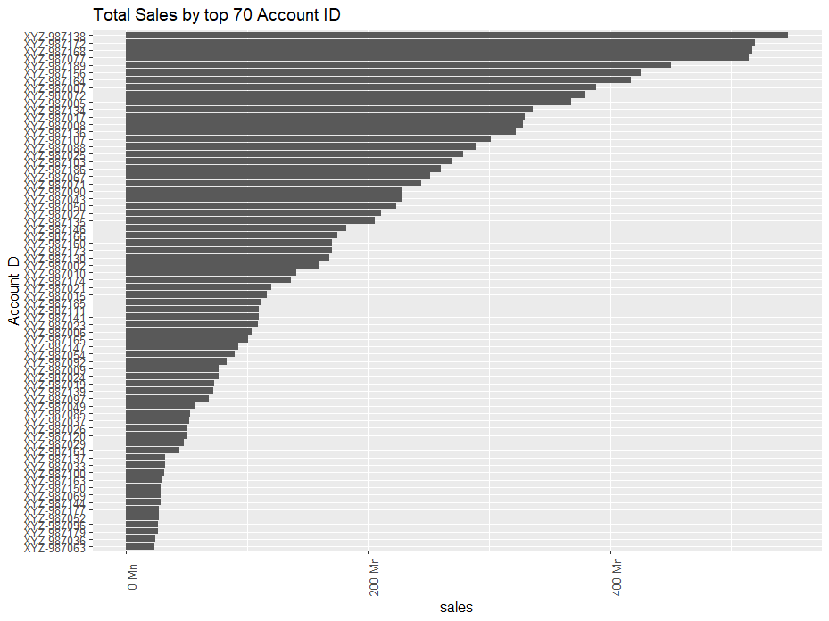

```r
df1 %>%
  group_by(accID) %>%
  summarise(sales = sum(sales, na.rm = T), .groups = "drop") %>%
  arrange(desc(sales)) %>%
  head(70) %>%

  ggplot(aes(x = fct_reorder(accID, sales, max), y = sales)) +
  geom_col() +
  theme(axis.text.x = element_text(angle = 90)) +
  scale_y_continuous(labels = unit_format(unit = "Mn", scale = 1e-6)) +
  labs(title = "Total Sales by top 70 Account ID",
       x = "Account ID") +
  coord_flip()
```

#### 0.2.4.3 Lin. Regression Plots

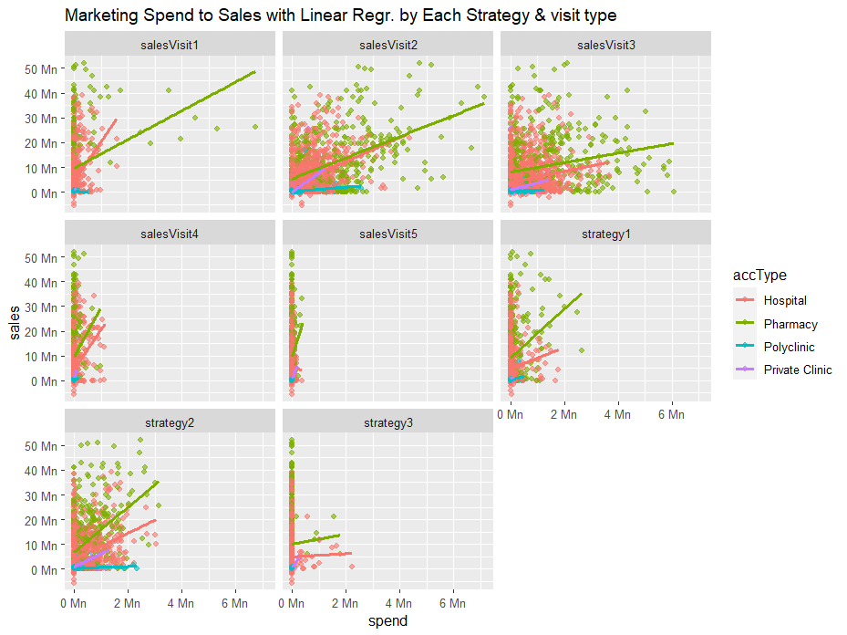

```r
df1 %>%
  pivot_longer(cols = strategy1:salesVisit5,
               names_to = "marketing_channel", values_to = "spend") %>%
  ggplot(aes(x = spend, y = sales, col = accType)) +
  geom_point(alpha = .6) +
  geom_smooth(method = "lm", se = FALSE) +
  facet_wrap(~marketing_channel) +
  scale_x_continuous(labels = unit_format(unit = "Mn", scale = 1e-6)) +
  scale_y_continuous(labels = unit_format(unit = "Mn", scale = 1e-6)) +
  labs(title = "Marketing Spend to Sales with Linear Regr. by Each Strategy & visit type")
```

Above plot,

1. Most Spend values comes from salesVisit1 to 3 in Pharmacy account Type
2. Strategy 1 & 2 shows best Return on Investment in Pharmacy

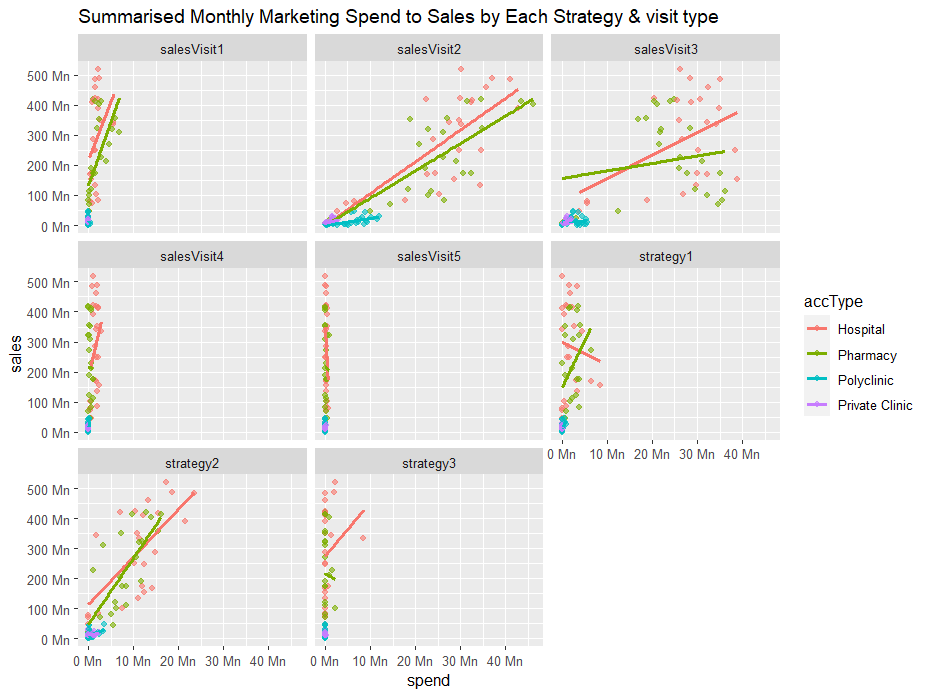

```r
df1 %>%

  select(month,accType, sales:salesVisit5) %>%
  group_by(month,accType) %>%
  summarise_at(vars(sales:salesVisit5), sum, na.rm = TRUE) %>%

  pivot_longer(cols = strategy1:salesVisit5,
               names_to = "marketing_channel", values_to = "spend") %>%
  ggplot(aes(x = spend, y = sales, col = accType)) +
  geom_point(alpha = .6) +
  geom_smooth(method = "lm", se = FALSE) +
  facet_wrap(~marketing_channel) +
  scale_x_continuous(labels = unit_format(unit = "Mn", scale = 1e-6)) +
  scale_y_continuous(labels = unit_format(unit = "Mn", scale = 1e-6)) +
  labs(title = "Summarised Monthly Marketing Spend to Sales by Each Strategy & visit type")
```

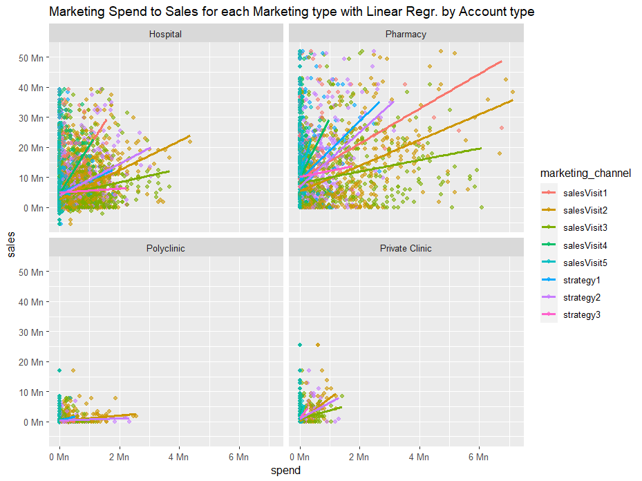

```r
df1 %>%
  pivot_longer(cols = strategy1:salesVisit5,
               names_to = "marketing_channel", values_to = "spend") %>%
  ggplot(aes(x = spend, y = sales, col = marketing_channel)) +
  geom_point(alpha = .6) +
  geom_smooth(method = "lm", se = FALSE) +
  facet_wrap(~accType) +
  scale_x_continuous(labels = unit_format(unit = "Mn", scale = 1e-6)) +
  scale_y_continuous(labels = unit_format(unit = "Mn", scale = 1e-6)) +
  labs(title = "Marketing Spend to Sales for each Marketing type with Linear Regr. by Account type")
```

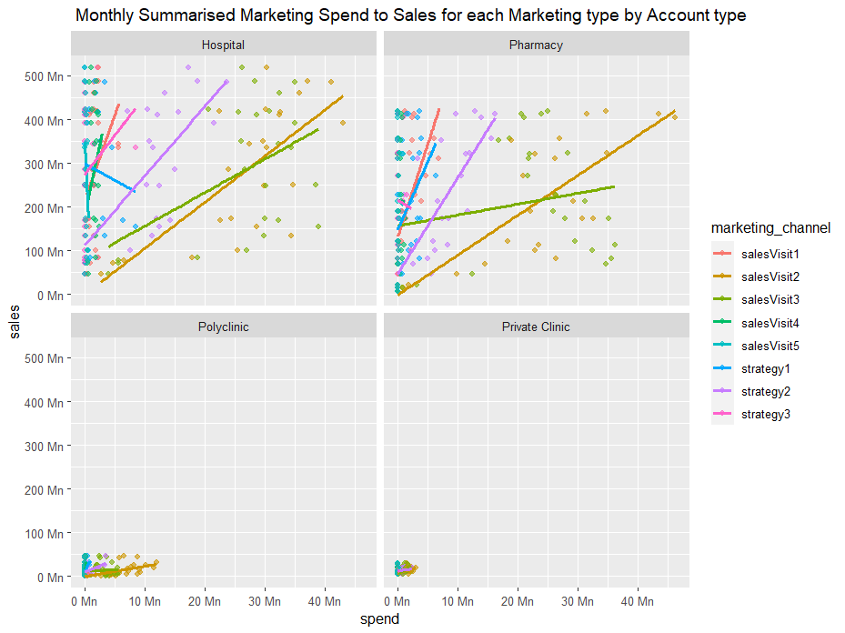

```r
df1 %>%
  select(month,accType, sales:salesVisit5) %>%
  group_by(month,accType) %>%
  summarise_at(vars(sales:salesVisit5), sum, na.rm = TRUE) %>%

  pivot_longer(cols = strategy1:salesVisit5,
               names_to = "marketing_channel", values_to = "spend") %>%
  ggplot(aes(x = spend, y = sales, col = marketing_channel)) +
  geom_point(alpha = .6) +
  geom_smooth(method = "lm", se = FALSE) +
  facet_wrap(~accType) +
  scale_x_continuous(labels = unit_format(unit = "Mn", scale = 1e-6)) +
  scale_y_continuous(labels = unit_format(unit = "Mn", scale = 1e-6)) +
  labs(title = " Monthly Summarised Marketing Spend to Sales for each Marketing type by Account type")
```

From Above, we may need to build Different Models for different Account Type as the effect of different marketing spends behave little different depending on Account type.